# Red Wine Data Exploration

### Faceting

Let’s analyse the residual sugar content in the wines faceted by quality. This would give us a fair idea about the distribution of residual sugar content across the different quality levels.

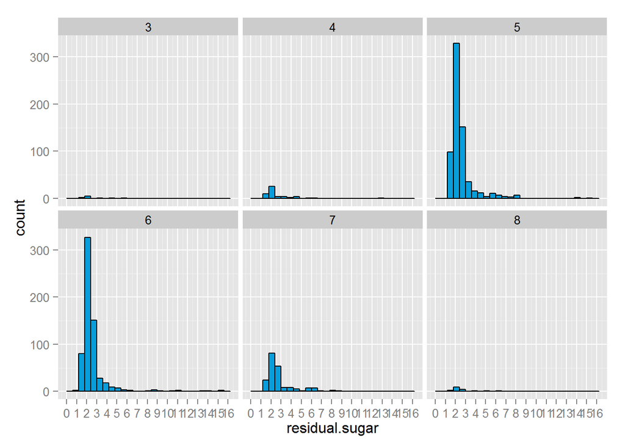

```r
qplot( data = redWineData,
       x = residual.sugar,
       binwidth = 0.6,
       color = I('black'),
       fill = I('#099DD9')
     ) +
  scale_x_continuous(breaks = seq(0,16,1)) +
  facet_wrap(~quality)
```

```r
max(redWineData$residual.sugar)
```

```
## [1] 15.5
```

The distribution of residual sugar is prominently seen in the facets showing quality 5 and 6. Most of these wines (having quality 5 and 6) have residual sugar content under 5.

```
## stat_bin: binwidth defaulted to range/30. Use 'binwidth = x' to adjust this.
```

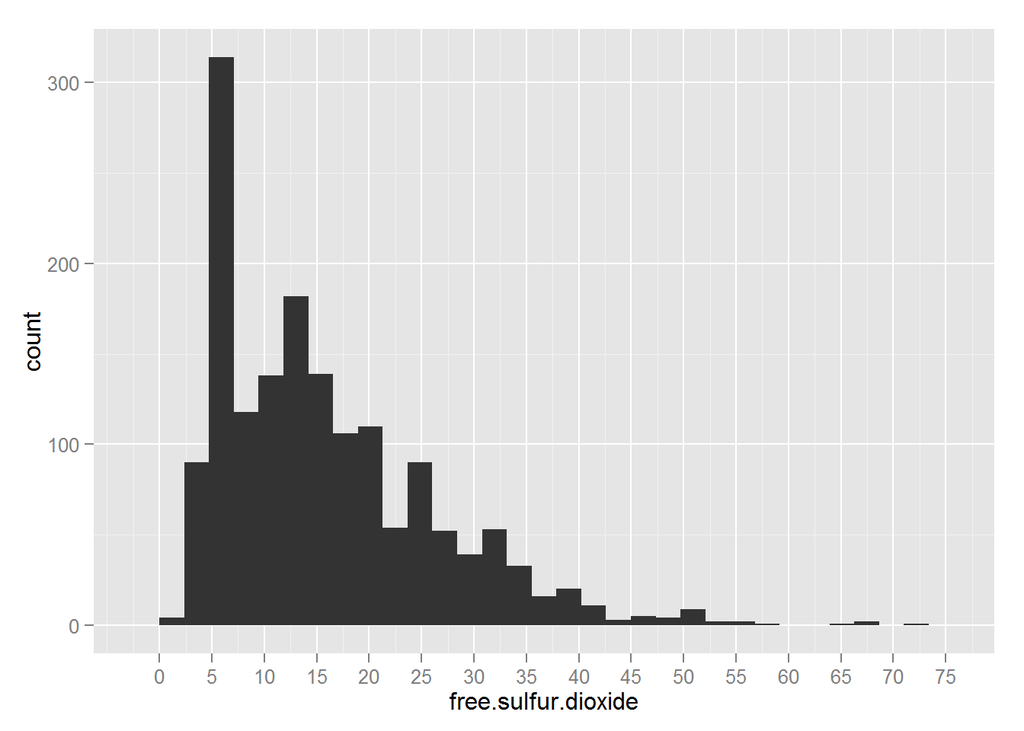

```r
qplot( data = redWineData,
       x = free.sulfur.dioxide,
     ) +
   scale_x_continuous(breaks = seq(0,75,5))
```

Majority of the samples have a free sulfur dioxide content under 30.

Now we are seeing a long tail here after free sulfur dioxide goes beyond 40. Lets add a log transformation to our code to address this issue.

```
## stat_bin: binwidth defaulted to range/30. Use 'binwidth = x' to adjust this.
```

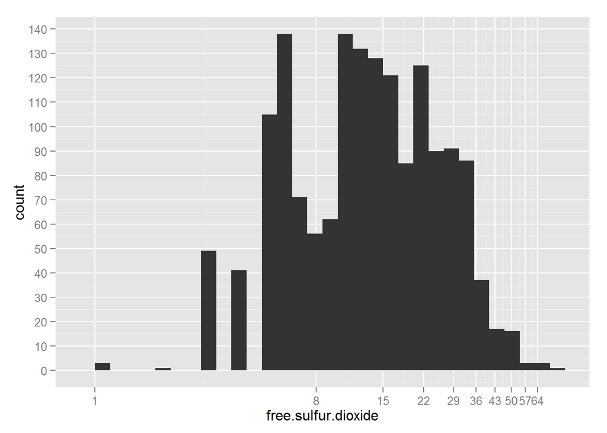

```r
library(scales)

qplot( data = redWineData,
       x = free.sulfur.dioxide,
     ) +
   scale_x_continuous(trans = log10_trans(), breaks = seq(1,70,7)) +
  scale_y_continuous(breaks = seq(0,140,10))
```

There are very few samples having free sulfur dioxude more than 35

Lets try the same variable with frequency polygon

### Frequency polygon

```
## stat_bin: binwidth defaulted to range/30. Use 'binwidth = x' to adjust this.
```

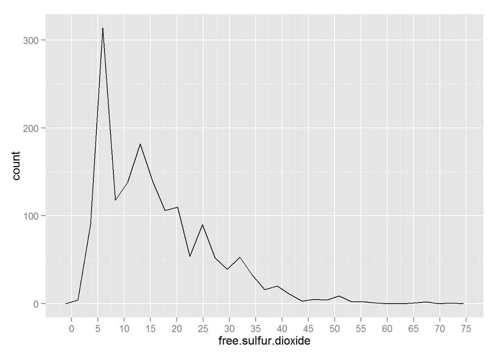

```r
qplot( data = redWineData,
       x = free.sulfur.dioxide,
       geom = 'freqpoly',
     ) +
  scale_x_continuous(breaks = seq(0,75,5))
```

Conclusion - Majority of the samples have a free sulfur dioxide content under 30.

```r
fsd_under30 <- subset(redWineData, free.sulfur.dioxide <= 30)
nrow(fsd_under30)
```

```
## [1] 1436
```

Our freq polygon results are verified. Approximately 90% of the samples have a free sulfur dioxide value under 30.

### Box Plots

Lets try to check out the quality of the samples against the alcohol content.

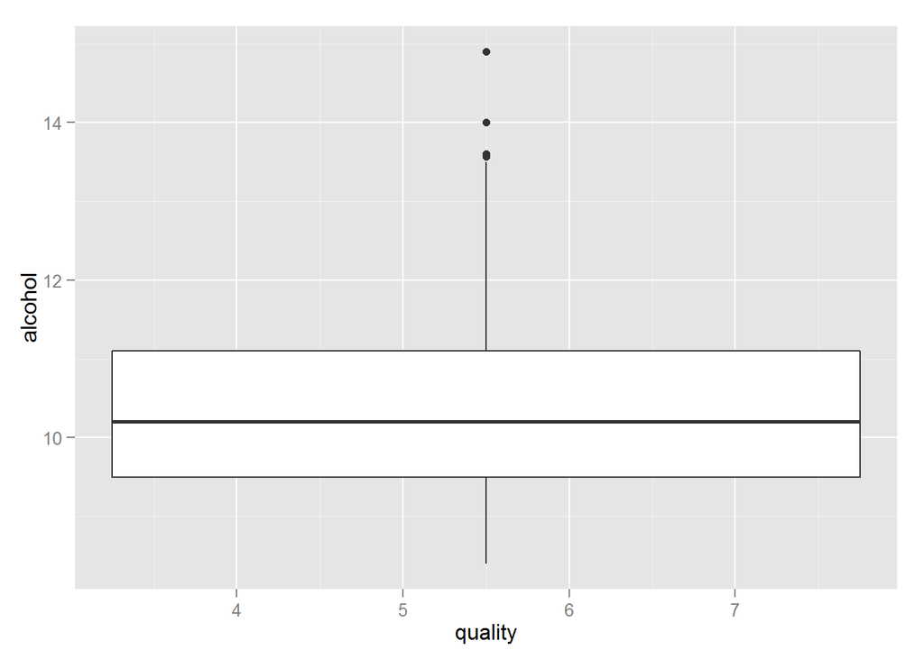

```r
qplot(data = redWineData,
      x = quality,
      y = alcohol,
      geom = 'boxplot',
    )
```

Here we will need to factor the variable quality first

### Factorisation

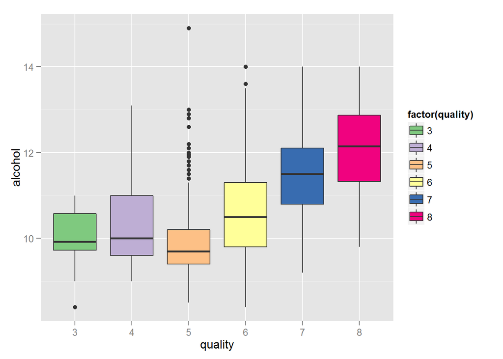

```r
redWineData$qualityfact <- factor(redWineData$quality,
                                  levels = c('1','2','3','4','5','6','7','8','9','10')
                                 )

library(RColorBrewer)

qplot(data = redWineData,
      x = qualityfact,
      y = alcohol,
      geom = 'boxplot',
      binwidth = 0.1,
      fill = factor(quality),
      xlab = "quality"
      ) +
  scale_fill_brewer(type = "qual")
```

Conclusion : Median alcohol content is highest for the samples with quality 8

Lets verify those results attained through the box plots

```r
by(redWineData$alcohol,redWineData$quality,summary)
```

```
## redWineData$quality: 3
##    Min. 1st Qu.  Median    Mean 3rd Qu.    Max.
##    8.40    9.72    9.93    9.96   10.60   11.00
## --------------------------------------------------------
## redWineData$quality: 4
##    Min. 1st Qu.  Median    Mean 3rd Qu.    Max.
##     9.0     9.6    10.0    10.3    11.0    13.1
## --------------------------------------------------------
## redWineData$quality: 5
##    Min. 1st Qu.  Median    Mean 3rd Qu.    Max.
##     8.5     9.4     9.7     9.9    10.2    14.9
## --------------------------------------------------------
## redWineData$quality: 6
##    Min. 1st Qu.  Median    Mean 3rd Qu.    Max.
##     8.4     9.8    10.5    10.6    11.3    14.0
## --------------------------------------------------------
## redWineData$quality: 7
##    Min. 1st Qu.  Median    Mean 3rd Qu.    Max.
##     9.2    10.8    11.5    11.5    12.1    14.0
## --------------------------------------------------------
## redWineData$quality: 8
##    Min. 1st Qu.  Median    Mean 3rd Qu.    Max.
##     9.8    11.3    12.2    12.1    12.9    14.0
```

Our results from the box-plot analysis are verified. Median alcohol content is indeed on the higher side for wines with high quality.

Lets test the impact of density on quality of the samples

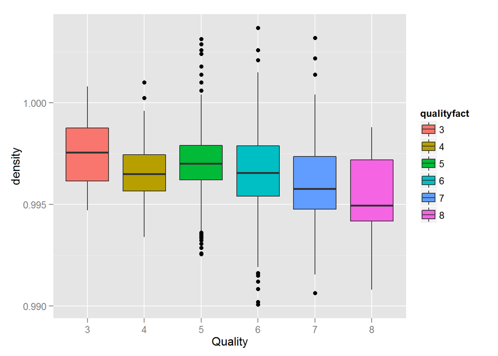

```r
ggplot( data = redWineData,
        aes(qualityfact,density, fill = qualityfact)
      ) +
  geom_boxplot() +
  xlab("Quality")
```

What we observe from the above plots is that, the median density is highest for the quality level 3 and in general, density of the samples goes on decreasing as the quality goes on increasing.

Now, lets test the impact of sulphate proportion on the quality of the samples

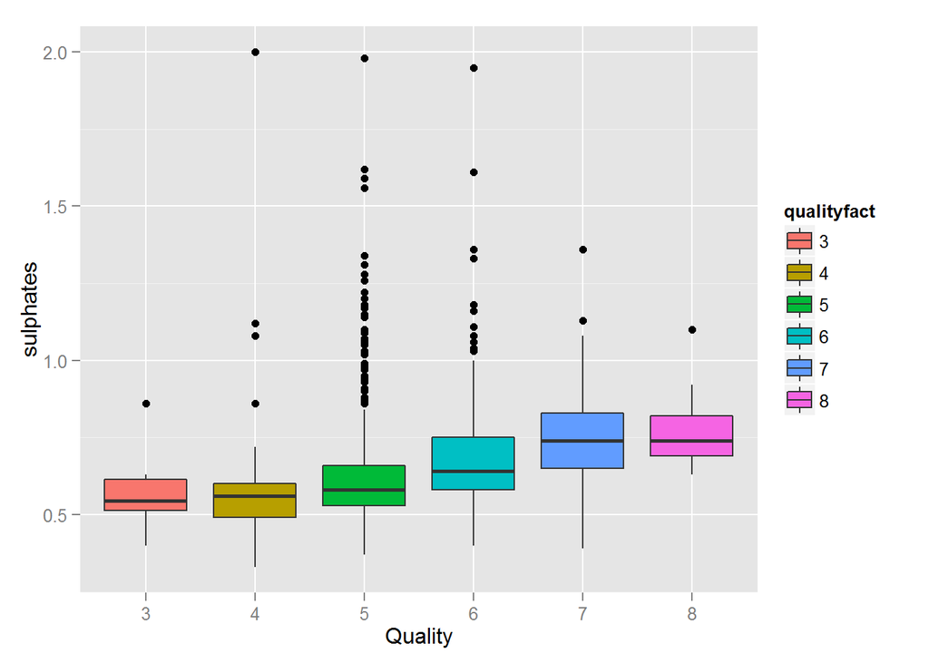

```r
ggplot( data = redWineData,
        aes(qualityfact,sulphates, fill = qualityfact)
      ) +
  geom_boxplot() +
  xlab("Quality")
```

What we see here is that as the quality goes on increasing the median content of sulphates goes on increasing.

### Revisiting the analysis goals

Let’s just get back to our purpose of doing this analysis. Let’s put our-self in the shoes of the Product Manager, for a moment. As a product manager, I would be interested in maximizing the quality of my product, the wine in this case and minimizing the cost of production. Such, data analysis of our current set of products and it’s ingredients can help me immensely as a Product Manager. I know a few important things

1. Current status of my products(quality, cost etc)
2. Contribution of the ingredients in deriving the kind of quality that they are deriving.
3. Possibilities of cost-cutting, in case we come up with an analysis that shows that too much of attention is being given to a costlier ingredient when, we can do away with cheaper ones, without having to sacrifice the quality much.

We have figured out from our univariate analysis that all the ingredients influence the quality of the redwine in some or the other ways. But in order to find out the ingredients which predominantly affect the quality of the redwine, we need to perform a bivariate analysis of these variables along with the quality

### Bivariate analysis using ggplot syntax

Fixed Acidity Vs Quality

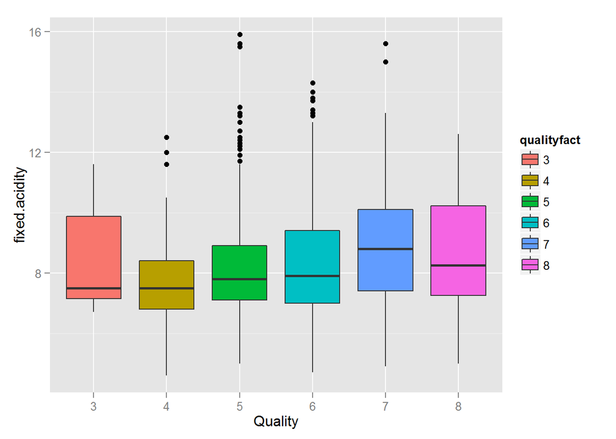

```r
ggplot( data = redWineData,
        aes(qualityfact, fixed.acidity, fill = qualityfact),
      ) +
  geom_boxplot() +
  xlab("Quality")
```

From the above box-plots, it is clear that fixed acidity remains fairly constant over all the quality levels.

Volatile acidity VS Quality

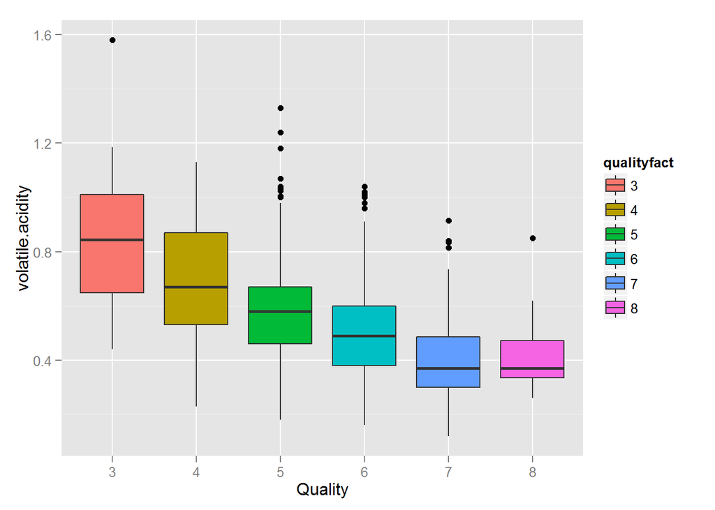

```r
ggplot( data = redWineData,
        aes(qualityfact, volatile.acidity, fill = qualityfact),
      ) +
  geom_boxplot() +
  xlab("Quality")
```

As the volatile acidity decreases the quality of the wine goes on increasing.

Citric acid VS Quality

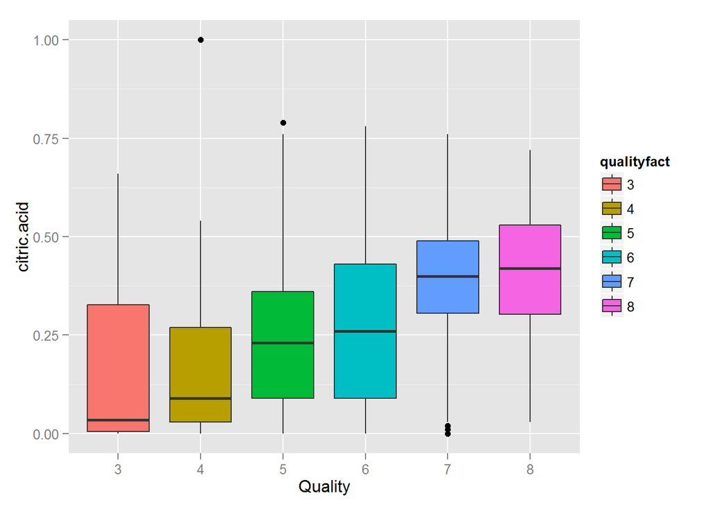

```r
ggplot( data = redWineData,
        aes(qualityfact, citric.acid, fill = qualityfact),
      ) +
  geom_boxplot() +
  xlab("Quality")
```

The quality of the redwines tends to have an increasing trend with an increase in citric acid.

Residual sugar VS Quality

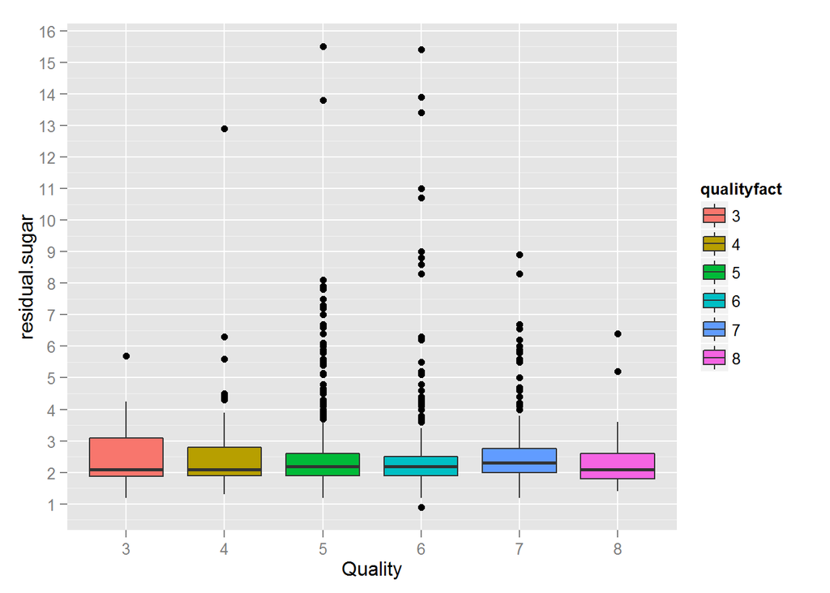

```r
ggplot( data = redWineData,
        aes(qualityfact, residual.sugar, fill = qualityfact),
      ) +
  geom_boxplot() +
  xlab("Quality") +
  scale_y_continuous(breaks = seq(0,16,1))
```

Here , we can guess that the residual sugar is more or less at the same level but the output is kinda squished because of the large number of outliers. Lets bring the focus on the box plots.

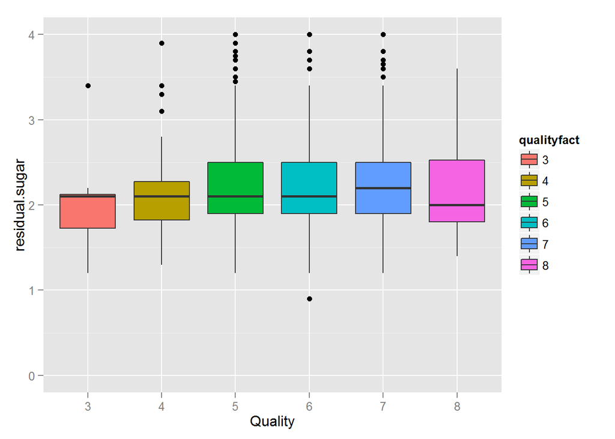

```r
ggplot( data = redWineData,
        aes(qualityfact, residual.sugar, fill = qualityfact),
      ) +
  geom_boxplot() +
  xlab("Quality") +
  scale_y_continuous(breaks = seq(0,16,1), limits = c(0,4))
```

The above box-plots show that, the amount of residual sugar remains fairly constant through all the quality levels.

Chlorides VS Quality

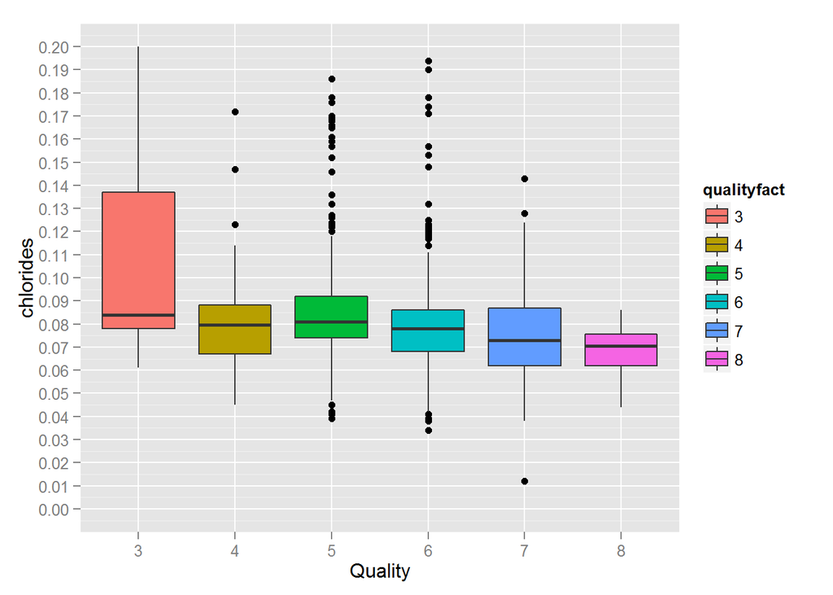

```r
ggplot( data = redWineData,
        aes(qualityfact, chlorides, fill = qualityfact)
      ) +
  geom_boxplot() +
  xlab("Quality") +
  scale_y_continuous(breaks = seq(0,0.2,0.01), limits = c(0,0.2))
```

The above box-plots show that, the amount of chlorides remains fairly constant through all the quality levels.

Free sulphur dioxide VS Quality

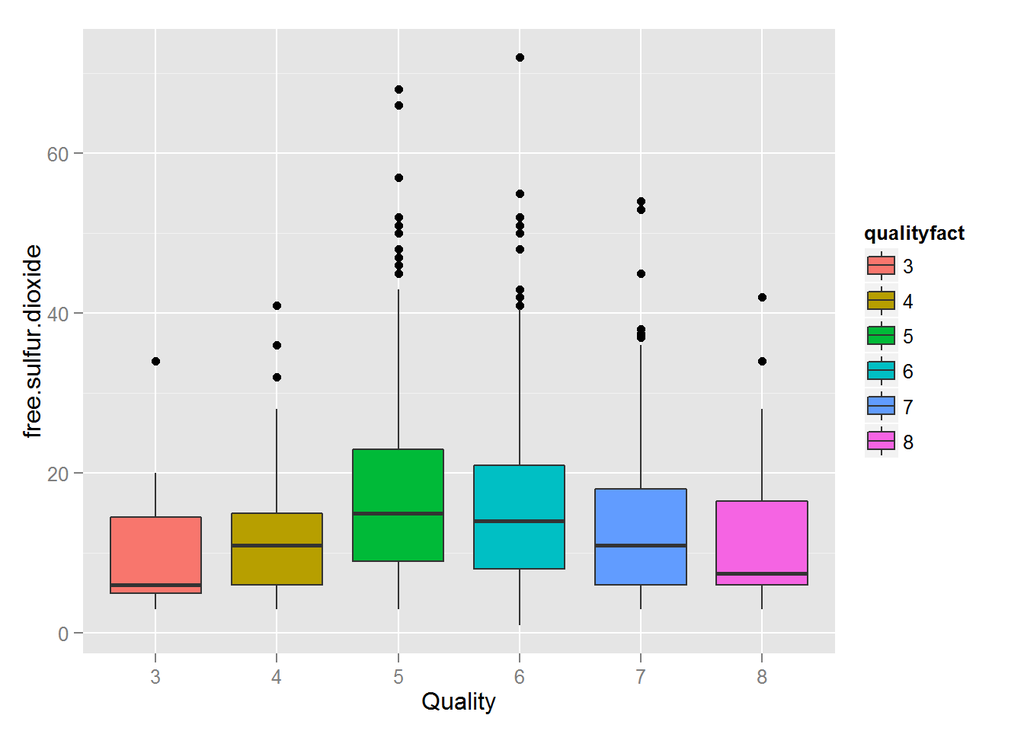

```r
ggplot( data = redWineData,
        aes(qualityfact,free.sulfur.dioxide, fill = qualityfact)
      ) +
  geom_boxplot() +
  xlab("Quality")
```

The amount of free sulphur dioxide varies across different quality levels.

Total Sulphur dioxide VS Quality

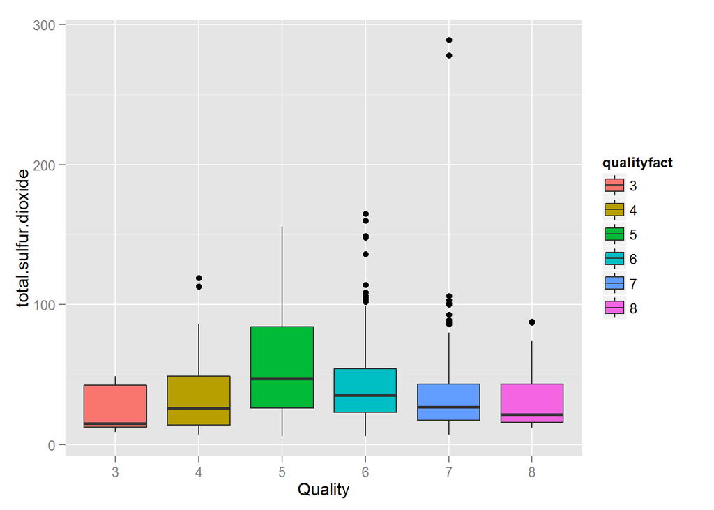

```r
ggplot( data = redWineData,
        aes(qualityfact,total.sulfur.dioxide, fill = qualityfact)
      ) +
  geom_boxplot() +
  xlab("Quality")
```

The trend of total sulphur dioxide is very similar to that of free sulphur dioxide w.r.t quality.

Density VS Quality

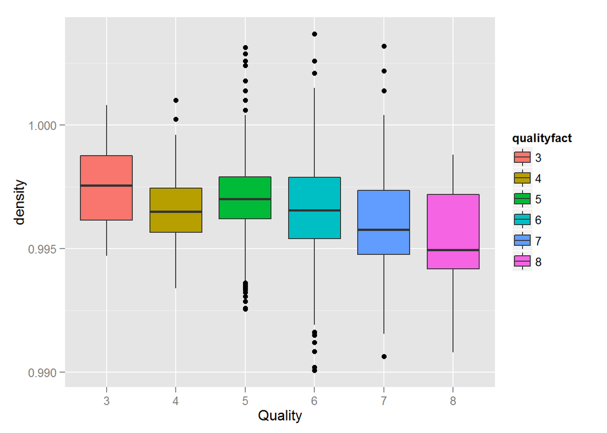

```r
ggplot( data = redWineData,
        aes(qualityfact,density, fill = qualityfact)
      ) +
  geom_boxplot() +
  xlab("Quality")
```

The density gradually decreases, as the quality goes on increasing.

pH vs Quality

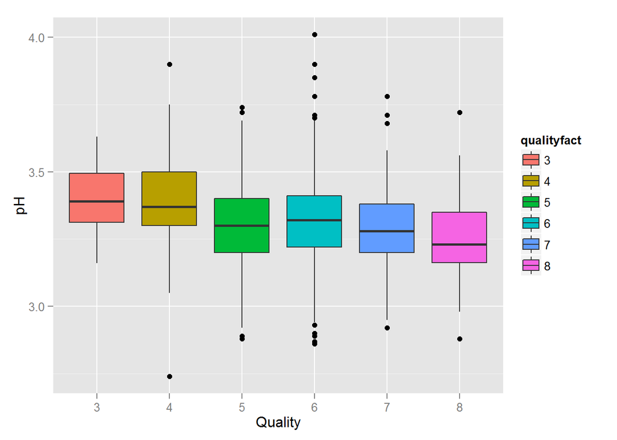

```r
ggplot( data = redWineData,
        aes(qualityfact,pH, fill = qualityfact)
      ) +
  geom_boxplot() +
  xlab("Quality")
```

sulphates VS Quality

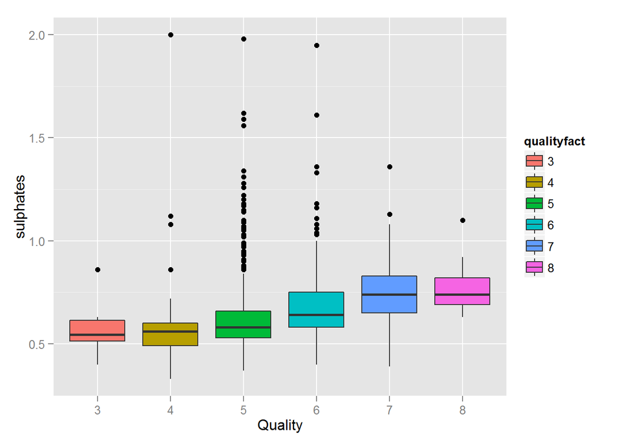

```r
ggplot( data = redWineData,
        aes(qualityfact, sulphates, fill = qualityfact)
      ) +
  geom_boxplot() +
  xlab("Quality")
```

With a steady increase in quality, increase in sulphates.

alcohol VS quality

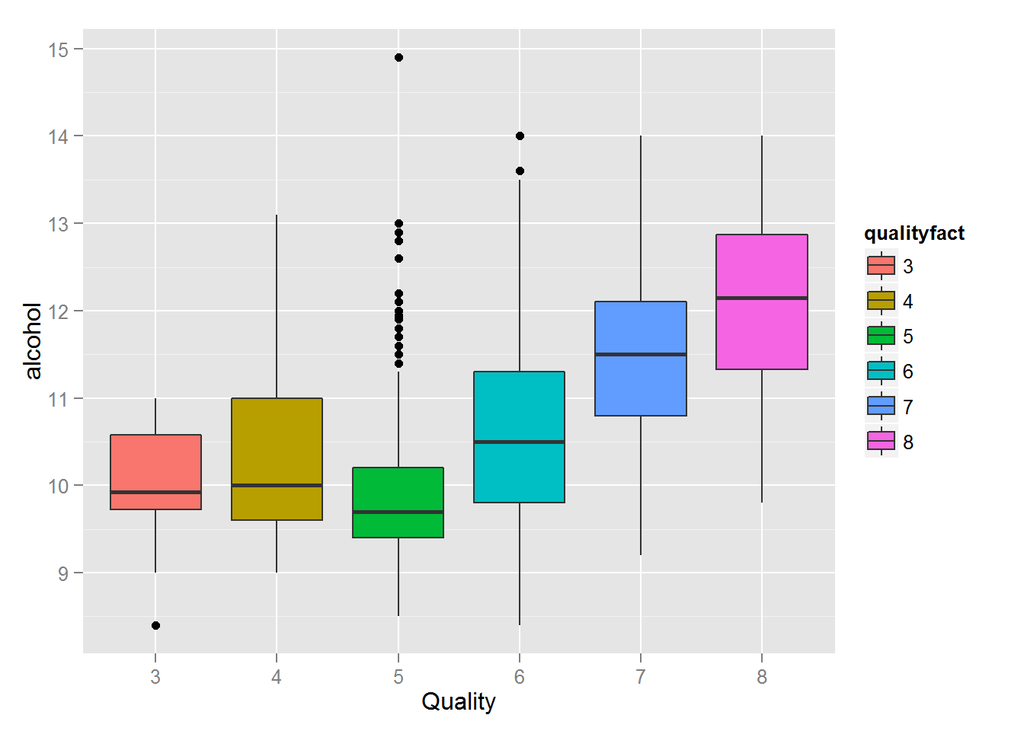

```r
ggplot( data = redWineData,
        aes(qualityfact,alcohol,fill = qualityfact)
      ) +
  geom_boxplot() +
  scale_y_continuous(breaks = seq(0,16,1)) +
  xlab("Quality")
```

What we see from the above plots is that, as the quality goes on improving the median alcohol content goes on increasing

Our analysis so far has been carried out with quality being the response variable and alcohol being the predictor variable.

Some of the variables have a strong impact on the quality of redwine while some don’t. However, it’s not clear from the analysis so far, whether these variables independently have an impact on the quality of the redwine or not. Is it because of the combination with some other variable, that the impact is created or not. We cannot be certain as of now about whether the impact is independent or not.

After doing a bit of research on the internet , I figured that chi-squared test could be a correct way to figure out which amongst the above variables have a dependency between them.

However chi-squared test is more suitable for identifying relationships between samples of the population.

We will have to test the interdependency between the factors affecting the quality of the redwine. A correlation coefficient matrix would come in handy for that purpose.

[figure not shown]

```r
library(GGally)
set.seed(1000)
good_quality_subset <- good_quality[,c(2:12)]

ggpairs(redWineData[sample.int(nrow(redWineData), ), ],
        title = "Interdependency between the ingredients"
       )
```

The following pairs of ingredients have a relatively strong correlation

1. Fixed Acidity and Citric Acid(+ve correlation)
2. Fixed Acidity and Density(+ve correlation)
3. Fixed Acidity and pH(-ve correlation)
4. Free Sulphur Dioxide and Total Sulphur Dioxide(+ve correlation)

This indicates that if one of the above factors affects the quality of the red wine then its impact is supplemented by the other factor that it has a strong correlation with.

Now that we have figured out that there is strong correlation between some of the ingredients, we know that value of one can help us in predicting the value of another. Linear regression could help us the recognize the change that needs to be brought up in one variable given a change in another variable.

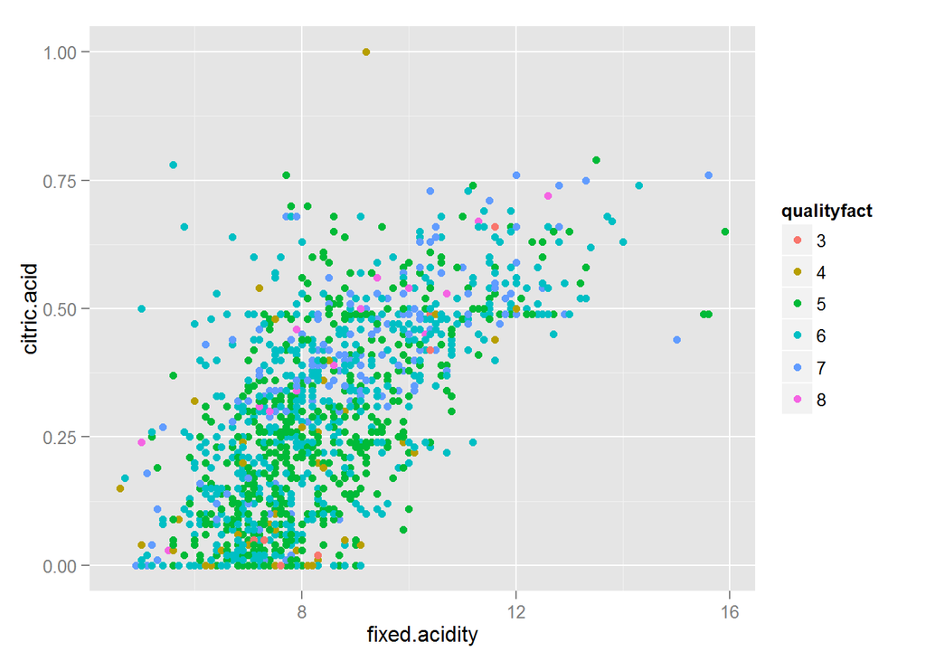

```r
ggplot( data = redWineData,
        aes(fixed.acidity, citric.acid, color = qualityfact),
      ) +
  geom_point()
```

The above scatterplot clearly indicates a linear dependency between fixed acidity and citric acid.

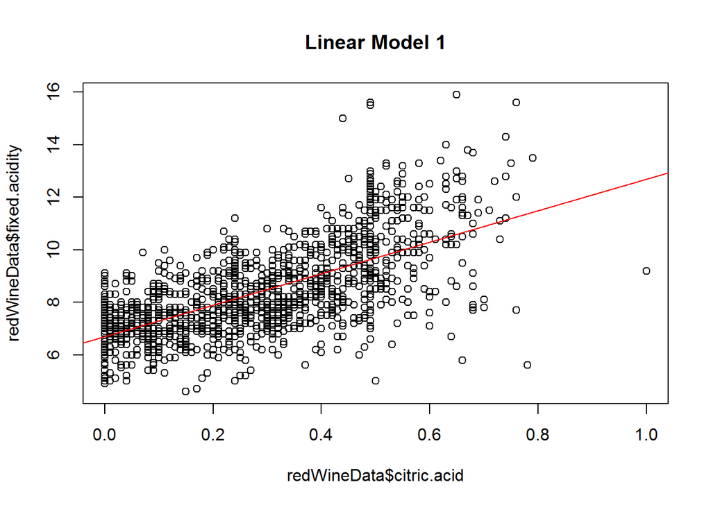

```r
linearModel1  <- lm(redWineData$fixed.acidity ~ redWineData$citric.acid)
plot(redWineData$fixed.acidity ~ redWineData$citric.acid, main = 'Linear Model 1')
abline(linearModel1,col = "red")
```

```r
summary(linearModel1)
```

```
##
## Call:
## lm(formula = redWineData$fixed.acidity ~ redWineData$citric.acid)
##
## Residuals:
##    Min     1Q Median     3Q    Max
## -5.776 -0.815 -0.033  0.806  5.965
##
## Coefficients:
##                         Estimate Std. Error t value Pr(>|t|)
## (Intercept)               6.6928     0.0553   121.0   <2e-16 ***
## redWineData$citric.acid   6.0036     0.1657    36.2   <2e-16 ***
## ---
## Signif. codes:  0 '***' 0.001 '**' 0.01 '*' 0.05 '.' 0.1 ' ' 1
##
## Residual standard error: 1.29 on 1597 degrees of freedom
## Multiple R-squared:  0.451,  Adjusted R-squared:  0.451
## F-statistic: 1.31e+03 on 1 and 1597 DF,  p-value: <2e-16
```

Since the p-value is less than 0.05(assuming the alpha = 0.05), we reject the null hypothesis that, there is no dependency between fixed acidity and citric acid.

fixed.acidity = 6.692 + citric.acid*6.003

Using the above equation, we can predict the fixed acidity given we have a citric acid content. The above equation can help us add fixed acidity and citric acid in a measured way in order to improve the quality of red wine samples that we have.

Similarly let us build some more linear models based on the results we have from the correlation matrix

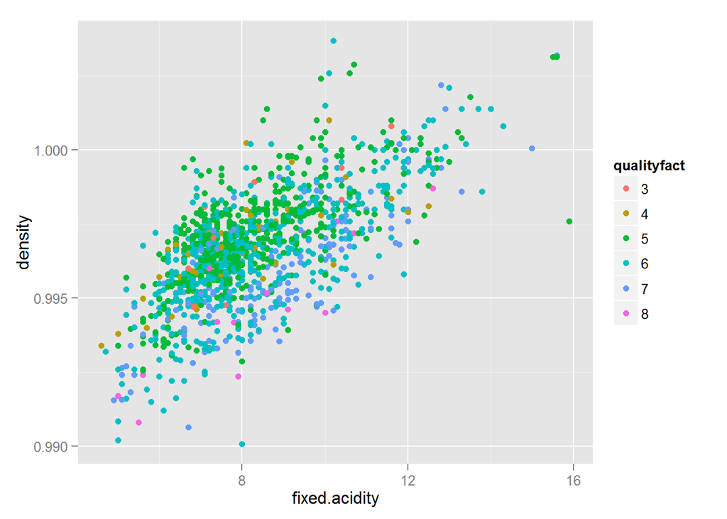

```r
ggplot( data = redWineData,
        aes(fixed.acidity, density, color = qualityfact),
      ) +
  geom_point()
```

Here again, we see a similar pattern of linear dependency between fixed acidity and density.

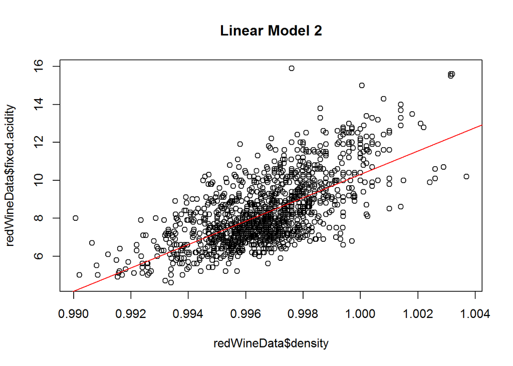

```r
linearModel2 <- lm(redWineData$fixed.acidity ~ redWineData$density)
plot(redWineData$fixed.acidity ~ redWineData$density, main = 'Linear Model 2')
abline(linearModel2,col = "red")
```

```r
summary(linearModel2)
```

```
##
## Call:
## lm(formula = redWineData$fixed.acidity ~ redWineData$density)
##
## Residuals:
##    Min     1Q Median     3Q    Max
## -3.355 -0.885 -0.241  0.804  7.054
##
## Coefficients:
##                     Estimate Std. Error t value Pr(>|t|)
## (Intercept)           -606.0       17.1   -35.4   <2e-16 ***
## redWineData$density    616.3       17.2    35.9   <2e-16 ***
## ---
## Signif. codes:  0 '***' 0.001 '**' 0.01 '*' 0.05 '.' 0.1 ' ' 1
##
## Residual standard error: 1.3 on 1597 degrees of freedom
## Multiple R-squared:  0.446,  Adjusted R-squared:  0.446
## F-statistic: 1.29e+03 on 1 and 1597 DF,  p-value: <2e-16
```

Since the p-value is less than 0.05(assuming the alpha = 0.05), we reject the null hypothesis that, there is no dependency between fixed acidity and density.

fixed.acidity = -605.96 + density * 616.28

Using the above equation, we can predict the fixed acidity using the density

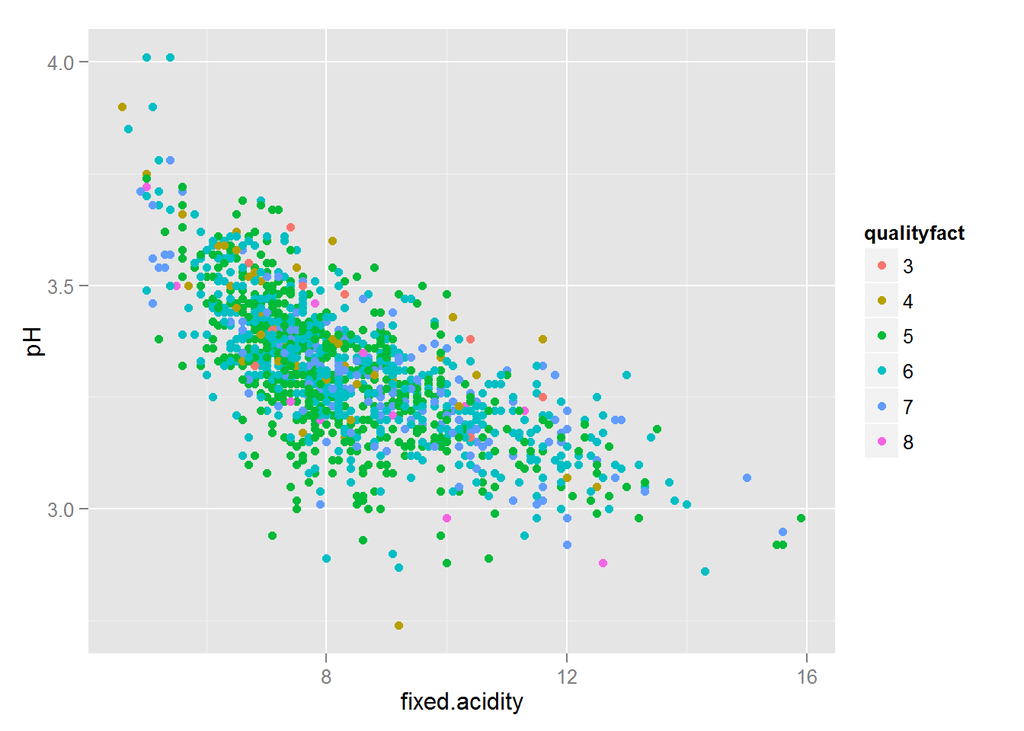

```r
ggplot(data = redWineData,
       aes(fixed.acidity, pH, color = qualityfact)
      ) +
  geom_point()
```

Now here is another interesting trend. We see a linear dependency between fixed acidity and pH. But it is a negative linear dependency.

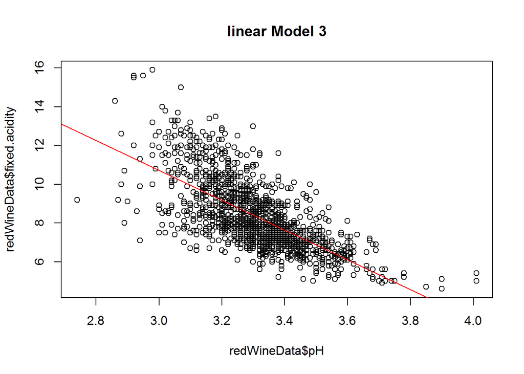

```r
linearModel3 <- lm(redWineData$fixed.acidity ~ redWineData$pH)
plot(redWineData$fixed.acidity ~ redWineData$pH, main = 'linear Model 3')
abline(linearModel3, col = "red")
```

```r
summary(linearModel3)
```

```
##
## Call:
## lm(formula = redWineData$fixed.acidity ~ redWineData$pH)
##
## Residuals:
##    Min     1Q Median     3Q    Max
## -4.078 -0.840 -0.155  0.682  5.030
##
## Coefficients:
##                Estimate Std. Error t value Pr(>|t|)
## (Intercept)      33.823      0.683    49.5   <2e-16 ***
## redWineData$pH   -7.702      0.206   -37.4   <2e-16 ***
## ---
## Signif. codes:  0 '***' 0.001 '**' 0.01 '*' 0.05 '.' 0.1 ' ' 1
##
## Residual standard error: 1.27 on 1597 degrees of freedom
## Multiple R-squared:  0.466,  Adjusted R-squared:  0.466
## F-statistic: 1.4e+03 on 1 and 1597 DF,  p-value: <2e-16
```

Since the p-value is less than 0.05(assuming the alpha = 0.05), we reject the null hypothesis that, there is no dependency between fixed acidity and pH.

fixed.acidity = 33.822 + pH*(-7.702)

Above equation indicates a negative linear dependency between fixed acidity and pH. In other words value of fixed acidity can be increasingly predicted with a decreasing value of pH

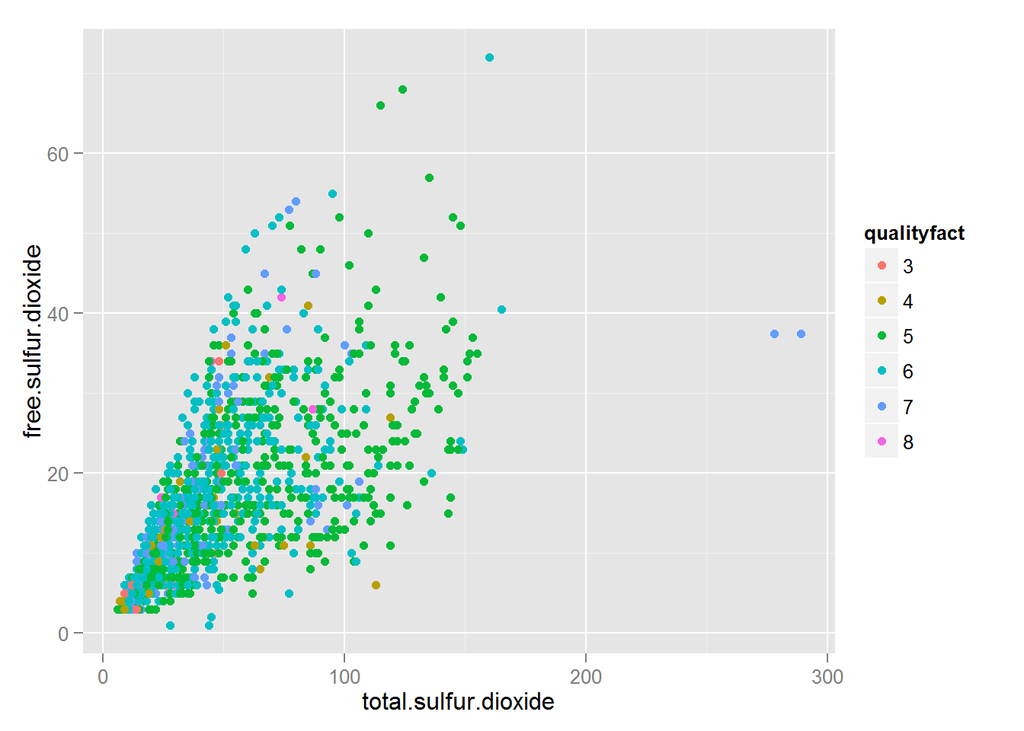

```r
ggplot( data = redWineData,
         aes(total.sulfur.dioxide,free.sulfur.dioxide,color = qualityfact)
       ) +
  geom_point()
```

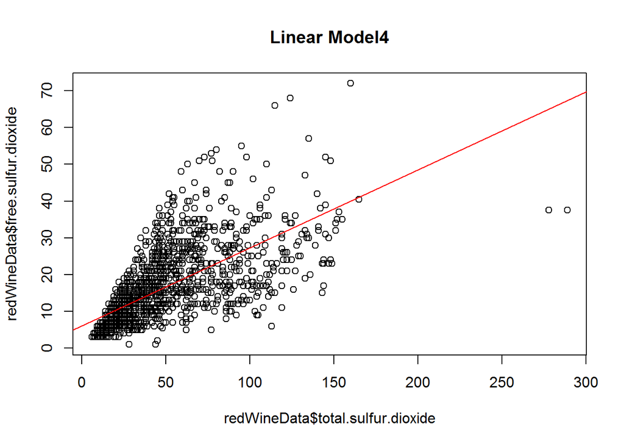

```r
linearModel4 <- lm(redWineData$free.sulfur.dioxide ~ redWineData$total.sulfur.dioxide)

plot(redWineData$free.sulfur.dioxide~redWineData$total.sulfur.dioxide, main = 'Linear Model4')
abline(linearModel4, col = "red")
```

```r
summary(linearModel4)
```

```
##
## Call:
## lm(formula = redWineData$free.sulfur.dioxide ~ redWineData$total.sulfur.dioxide)
##
## Residuals:
##    Min     1Q Median     3Q    Max
## -29.87  -4.41  -1.77   3.57  35.66
##
## Coefficients:
##                                  Estimate Std. Error t value Pr(>|t|)
## (Intercept)                       6.00950    0.33722    17.8   <2e-16 ***
## redWineData$total.sulfur.dioxide  0.21231    0.00592    35.8   <2e-16 ***
## ---
## Signif. codes:  0 '***' 0.001 '**' 0.01 '*' 0.05 '.' 0.1 ' ' 1
##
## Residual standard error: 7.79 on 1597 degrees of freedom
## Multiple R-squared:  0.446,  Adjusted R-squared:  0.445
## F-statistic: 1.28e+03 on 1 and 1597 DF,  p-value: <2e-16
```

Since the p-value is less than 0.05(assuming the alpha = 0.05), we reject the null hypothesis that, there is no dependency between free and total sulfur dioxide.

free.sulfur.dioxide = 6.009 + 0.212 * total.sulfur.dioxide

Above equation helps us in predicting the free sulphur dioxde given the total sulfur dioxide.

Let us just review our work so far. We started off, with uni-variate analysis then moved to bi-variate analysis with quality as one of the two variables. Here, we noticed certain ingredients having a strong impact on the quality of the redwines. This led us to a conclusion that the following variables have a strong impact on the quality of the redwines. -> Fixed acidity -> Citric acid -> Density -> pH -> Free sulfur dioxide -> Total sulfur dioxide

In order to figure out how, the impact happens in tandem, we built a correlation coefficient matrix. This led us to the understanding that certain pairs of ingredients have a strong inter-dependency between themselves. This led us further to building predictive linear model equations between these variables. These equations will help us in predicting the amounts of ingredients that we should add in order to improve the quality of the red wines.

Now lets find out the collective impact of the above mentioned ingredients on the quality of the redwines through multiple regression linear model equation

```r
linearModelQuality <- lm(redWineData$quality ~ redWineData$fixed.acidity + redWineData$citric.acid + redWineData$density + redWineData$pH + redWineData$free.sulfur.dioxide + redWineData$total.sulfur.dioxide)

summary(linearModelQuality)
```

```
##
## Call:
## lm(formula = redWineData$quality ~ redWineData$fixed.acidity +
##     redWineData$citric.acid + redWineData$density + redWineData$pH +
##     redWineData$free.sulfur.dioxide + redWineData$total.sulfur.dioxide)
##
## Residuals:
##     Min      1Q  Median      3Q     Max
## -3.0496 -0.4823 -0.0699  0.5025  2.3566
##
## Coefficients:
##                                   Estimate Std. Error t value Pr(>|t|)
## (Intercept)                       1.81e+02   1.36e+01   13.30  < 2e-16 ***
## redWineData$fixed.acidity         1.51e-01   2.23e-02    6.75  2.1e-11 ***
## redWineData$citric.acid           1.03e+00   1.30e-01    7.91  4.9e-15 ***
## redWineData$density              -1.80e+02   1.39e+01  -12.93  < 2e-16 ***
## redWineData$pH                    6.90e-01   1.72e-01    4.01  6.4e-05 ***
## redWineData$free.sulfur.dioxide   1.05e-02   2.37e-03    4.41  1.1e-05 ***
## redWineData$total.sulfur.dioxide -5.13e-03   7.92e-04   -6.48  1.2e-10 ***
## ---
## Signif. codes:  0 '***' 0.001 '**' 0.01 '*' 0.05 '.' 0.1 ' ' 1
##
## Residual standard error: 0.726 on 1592 degrees of freedom
## Multiple R-squared:  0.194,  Adjusted R-squared:  0.191
## F-statistic: 63.9 on 6 and 1592 DF,  p-value: <2e-16
```

The following factors help us in expanding our knowledge of the linear model that we have generated.

```r
coefficients(linearModelQuality)
```

```
##                      (Intercept)        redWineData$fixed.acidity
##                        180.84225                          0.15058
##          redWineData$citric.acid              redWineData$density
##                          1.03062                       -179.53467
##                   redWineData$pH  redWineData$free.sulfur.dioxide
##                          0.69001                          0.01046
## redWineData$total.sulfur.dioxide
##                         -0.00513
```

Coefficents gives us the list of coefficients generated in our linear model.

```r
confint(linearModelQuality, level = 0.95)
```

```
##                                       2.5 %     97.5 %
## (Intercept)                       1.542e+02  2.075e+02
## redWineData$fixed.acidity         1.068e-01  1.944e-01
## redWineData$citric.acid           7.750e-01  1.286e+00
## redWineData$density              -2.068e+02 -1.523e+02
## redWineData$pH                    3.524e-01  1.028e+00
## redWineData$free.sulfur.dioxide   5.809e-03  1.511e-02
## redWineData$total.sulfur.dioxide -6.682e-03 -3.577e-03
```

```r
fitted(linearModelQuality)
```

[output not shown]

[output cut: 213 more lines]

[output not shown]

```r
residuals(linearModelQuality)
```

[output not shown]

[output cut: 479 more lines]

[output not shown]

The residuals function gives us the amount of deviation from the linear model generated.

Let us build some additional density plots in order to gain more information on our dataset

### Cutting a variable

Let us cut the variable quality in order to distribute the samples over buckets of variable quality

```r
redWineData$quality_bucket <- cut(redWineData$quality,c(1,3,6,8,10),
                                  labels = c('1-3','3-6','6-8','8-10')
                                  )
```

### Density plots

Lets create density plots for a few of the variables

```r
library(gridExtra)
```

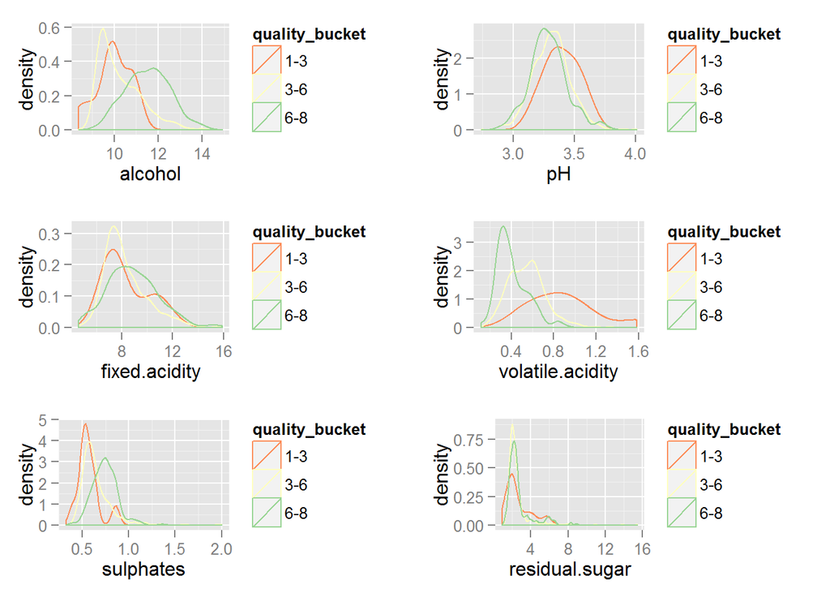

```r
p1 <- ggplot( data = redWineData,
              aes(alcohol,color = quality_bucket)
            ) +
  geom_density() +
  scale_color_brewer(palette = "Spectral")

p2 <- ggplot( data = redWineData,
              aes(pH,color = quality_bucket)
            ) +
  geom_density() +
  scale_color_brewer(palette = "Spectral")

p3 <- ggplot( data = redWineData,
              aes(fixed.acidity,color = quality_bucket)
            ) +
  geom_density() +
  scale_color_brewer(palette = "Spectral")

p4 <- ggplot( data = redWineData,
              aes(volatile.acidity,color = quality_bucket)
            ) +
  geom_density() +
  scale_color_brewer(palette = "Spectral")

p5 <- ggplot( data = redWineData,
              aes(sulphates,color = quality_bucket)
            ) +
  geom_density() +
  scale_color_brewer(palette = "Spectral")

p6 <- ggplot( data = redWineData,
              aes(residual.sugar,color = quality_bucket)
            ) +
  geom_density() +
  scale_color_brewer(palette = "Spectral")

grid.arrange(p1,p2,p3,p4,p5,p6,ncol = 2)
```

The above plots show the distribution of various ingredients over their respective quality buckets.

### Sampling

Sampling is’nt going to help us much here, because we don’t really have any trends to analyze in this data set. It’s just a dataset of 1599 unique wines.

### Plot 1

```
## stat_bin: binwidth defaulted to range/30. Use 'binwidth = x' to adjust this.
## stat_bin: binwidth defaulted to range/30. Use 'binwidth = x' to adjust this.
```

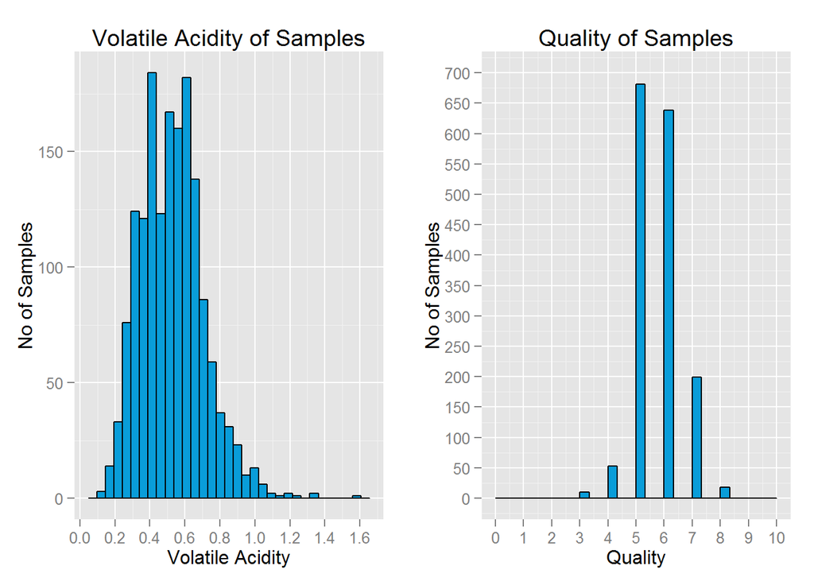

```r
p1 <- qplot(data = redWineData,
            volatile.acidity,
            color = I('black'),
            fill = I('#099DD9'),
            position = "identity",
            xlab = "Volatile Acidity",
            ylab = "No of Samples"
            ) +
  scale_x_continuous(breaks = seq(0,2,0.2)) +
  ggtitle('Volatile Acidity of Samples')

p2 <- qplot( data = redWineData,
             x = quality,
             color = I('black'),
             fill = I('#099DD9'),
             xlab = "Quality",
             ylab = "No of Samples"
            ) +
  scale_x_continuous(breaks = seq(0,10,1), limits = c(0,10)) +
  scale_y_continuous(breaks = seq(0,700,50),limits = c(0,700)) +
  ggtitle('Quality of Samples')

grid.arrange(p1, p2, ncol = 2)
```

The above plots raise a suspicion about the fact that in order to attain a quality level of 5 or 6 which majority of the samples in our data set have attained, it is necessary that the volatile acidity is between 0.3 to 0.7. But we cannot yet be confident about our suspicion, in order to gain confidence in our claim we need to subset data with volatile acidity 0.3 and 0.7 and check the quality of that data.

```r
max_va_redWineData <- subset(redWineData,
                             redWineData$volatile.acidity >= 0.3 &  redWineData$volatile.acidity     <= 0.7)

nrow(max_va_redWineData)
```

```
## [1] 1249
```

```r
guess_data <- subset(max_va_redWineData,
                     max_va_redWineData$quality == 5 | max_va_redWineData$quality == 6
                     )

nrow(guess_data)
```

```
## [1] 1051
```

### Plot 2

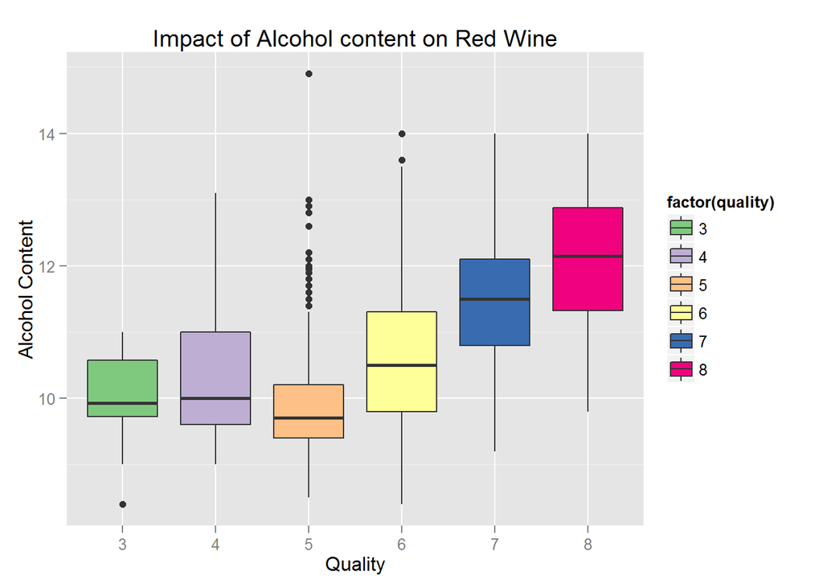

```r
redWineData$qualityfact <- factor(redWineData$quality,
                                  levels = c('1','2','3','4','5','6','7','8','9','10')
                                  )

library(RColorBrewer)

qplot(data = redWineData,
      x = qualityfact,
      y = alcohol,
      geom = 'boxplot',
      binwidth = 0.1,
      fill = factor(quality),
      xlab = "Quality",
      ylab = "Alcohol Content"
      ) +
  scale_fill_brewer(type = "qual") +
  ggtitle('Impact of Alcohol content on Red Wine')
```

```r
  by(redWineData$alcohol,redWineData$quality,summary)
```

```
## redWineData$quality: 3
##    Min. 1st Qu.  Median    Mean 3rd Qu.    Max.
##    8.40    9.72    9.93    9.96   10.60   11.00
## --------------------------------------------------------
## redWineData$quality: 4
##    Min. 1st Qu.  Median    Mean 3rd Qu.    Max.
##     9.0     9.6    10.0    10.3    11.0    13.1
## --------------------------------------------------------
## redWineData$quality: 5
##    Min. 1st Qu.  Median    Mean 3rd Qu.    Max.
##     8.5     9.4     9.7     9.9    10.2    14.9
## --------------------------------------------------------
## redWineData$quality: 6
##    Min. 1st Qu.  Median    Mean 3rd Qu.    Max.
##     8.4     9.8    10.5    10.6    11.3    14.0
## --------------------------------------------------------
## redWineData$quality: 7
##    Min. 1st Qu.  Median    Mean 3rd Qu.    Max.
##     9.2    10.8    11.5    11.5    12.1    14.0
## --------------------------------------------------------
## redWineData$quality: 8
##    Min. 1st Qu.  Median    Mean 3rd Qu.    Max.
##     9.8    11.3    12.2    12.1    12.9    14.0
```

After doing a bit of research on google I found out that, alcohol contents in a wine can also depend upon the climatic conditions of the region where it is produced. Majority of the red wines have an alcohol content between 10-15%. However there are a few exceptions which go as high as beyond 20% but with further increase in alcohol content, the red wine starts loosing its charm.

### Plot 3

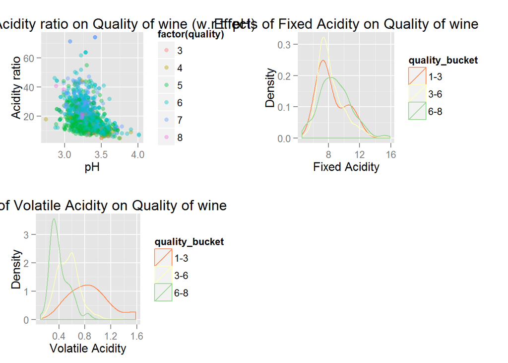

```r
library(ggplot2)
library(gridExtra)
p1 <- ggplot(data = redWineData,
             aes(pH, fixed.acidity/volatile.acidity, color = factor(quality))
            ) +
  geom_point(alpha = 2/5) +
  ylab("Acidity ratio") +
  ggtitle('Effects of Acidity ratio on Quality of wine (w.r.t. pH)')


p2 <- ggplot( data = redWineData,
              aes(fixed.acidity,color = quality_bucket)
            ) +
  geom_density() +
  scale_color_brewer(palette = "Spectral") +
  xlab("Fixed Acidity") +
  ylab("Density") +
  ggtitle('Effects of Fixed Acidity on Quality of wine')


p3 <- ggplot( data = redWineData,
              aes(volatile.acidity,color = quality_bucket)
            ) +
  geom_density() +
  scale_color_brewer(palette = "Spectral") +
  xlab("Volatile Acidity") +
  ylab("Density") +
  ggtitle('Effects of Volatile Acidity on Quality of wine')


grid.arrange(p1,p2,p3,ncol = 2)
```

```r
sd1 <- subset(redWineData, quality_bucket == '3-6')
nrow(sd1)
```

```
## [1] 1372
```

Also, if we take a look at the two density plots,

Volatile Acidity -> The number of samples in the quality bucket 1-3 are far more spread out over the volatile acidity range.